# Lab5 Checkpoint1

Leticia Wanderley

15 de agosto de 2017

## Dados

Para esta análise serão utilizados dados de “speed dating”. Speed dating é uma forma de conhecer muitas pessoas novas rapidamente. Nessa “modalidade” de encontros, várias pessoas se reúnem em um lugar público, como um restaurante, e passam alguns poucos minutos conversando em duplas. Depois que esses minutos se passam as duplas são trocadas e o cronômetro é resetado. Os dados foram obtidos dos participantes desses encontros. Cada participante foi convidado a responder um formulário após cada encontro descrevendo suas impressões sobre a pessoa encontrada. As impressões variam de características físicas, como atratividade (ou nível de atração), para características psicológicas, como sinceridade.

## Perguntas

### Quais os atributos que mais influenciam no “gostar”?

Além de descrever suas impressões sobre as outras pessoas, os participantes também informavam o quanto gostaram da outra pessoa. Esta primeira análise tenta descobrir quais atributos mais influenciam no quanto uma pessoa agrada a outra.

#### Interesses em comum e atração

Após uma análise exploratória inicial se percebeu que, como esperado, se duas pessoas tem muitos interesses em comum elas provavelmente gostam mais uma da outra. Outro fator muito influente é o nível de atração que uma pessoa exerce sobre a outra. Ou seja, [*beleza é fundamental*](http://www.viniciusdemoraes.com.br/pt-br/poesia/poesias-avulsas/receita-de-mulher).

```r
set.seed(1)
mod_shar_attr <- lm(like ~ shar + attr, data = dates)
tidy(mod_shar_attr, conf.int = TRUE)
```

```
##          term  estimate  std.error statistic       p.value  conf.low
## 1 (Intercept) 1.2190121 0.10247983  11.89514  2.430869e-31 1.0180051
## 2        shar 0.3603912 0.01451987  24.82056 1.629733e-115 0.3319115
## 3        attr 0.4736062 0.01670473  28.35162 6.523550e-144 0.4408410
##   conf.high
## 1 1.4200192
## 2 0.3888709
## 3 0.5063714
```

O resultado da regressão linear utilizando tanto o valor de interesses em comum e atração mostra que os dois atributos tem significância no “gostar”. Um ponto no quesito “interesses em comum” aumenta 0.36 no valor do “gostar” e um ponto no quesito “atração” aumenta 0.47. No modelo encontrado, o valor do “gostar” quando os valores dos dois atributos é zero é de 1.21 pontos.

```r
glance(mod_shar_attr)
```

```
##   r.squared adj.r.squared    sigma statistic p.value df    logLik      AIC
## 1 0.6061259     0.6056394 1.140458  1245.725       0  3 -2513.197 5034.393
##        BIC deviance df.residual
## 1 5055.959 2105.745        1619
```

Ao se observar o valor do R quadrado ajustado, se percebe que os atributos interesses em comum e atração explicam 60% do valor do “gostar”.

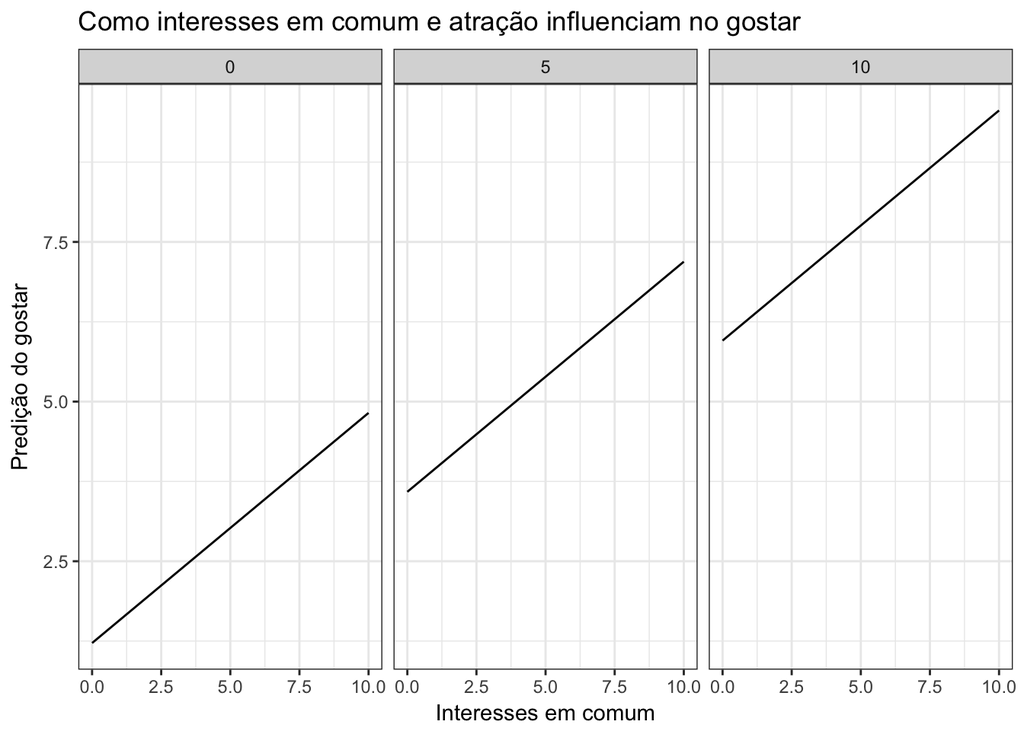

```r
modelo_shar_attr = dates %>%
  data_grid(shar = seq_range(shar, 10),
            attr = seq_range(attr, 3)) %>%
  add_predictions(mod_shar_attr)

modelo_shar_attr %>%
  ggplot(aes(x = shar, y = pred)) +
  geom_line() +
  facet_grid(. ~ attr) +
  labs(title="Como interesses em comum e atração influenciam no gostar", x="Interesses em comum", y="Predição do gostar")
```

No gráfico acima se pode observar que, como já visto, quanto maior o valor da atração (cada retângulo representa um range de valores) mais alto é o ponto inicial da reta. A inclinação é igual para todas as retas, já que ela só representa a variável independente “interesses em comum”.

#### Mais atributos influentes

Os atributos mais influentes e significativos no “gostar” são 4. Interesses em comum e atração, como já visto, seguidos por o quão a pessoa parece ser divertida e o quão ela parece ser sincera.

```r
set.seed(1)
mod_most <- lm(like ~ shar + attr + fun + sinc, data = dates)
tidy(mod_most, conf.int = TRUE)
```

```
##          term  estimate  std.error statistic      p.value   conf.low
## 1 (Intercept) 0.2908008 0.11477988  2.533552 1.138508e-02 0.06566785
## 2        shar 0.2525279 0.01519189 16.622553 2.100371e-57 0.22273006
## 3        attr 0.3421748 0.01752635 19.523446 2.176529e-76 0.30779806
## 4         fun 0.1910815 0.01956213  9.767933 6.162451e-22 0.15271174
## 5        sinc 0.1587513 0.01806963  8.785532 3.889384e-18 0.12330895
##   conf.high
## 1 0.5159337
## 2 0.2823258
## 3 0.3765516
## 4 0.2294513
## 5 0.1941937
```

Os quatro atributos aumentam entre 0.34 e 0.15 no valor atribuído ao “gostar”. Isso quer dizer que a cada ponto a mais no valor desses quesitos o valor do gostar aumenta entre 0.34 e 0.15, dependendo do quesito. O valor do “gostar” quando todos os valores dos atributos são nulos é 0.29.

```r
glance(mod_most)
```

```
##   r.squared adj.r.squared    sigma statistic p.value df    logLik      AIC
## 1 0.6614666     0.6606292 1.057962  789.8716       0  5 -2390.404 4792.809
##        BIC deviance df.residual
## 1 4825.157  1809.88        1617
```

O modelo gerado por esses 4 atributos explica 66% do valor do “gostar”, como se pode observar pelo R quadrado ajustado. (A adição dos outros dois atributos restantes, inteligência e ambição, aumenta em torno de 0.3% o valor do R quadrado ajustado.)

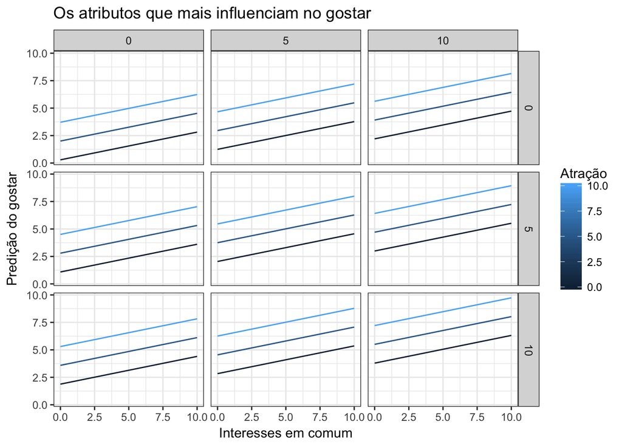

```r
modelo_most = dates %>%
  data_grid(shar = seq_range(shar, 3),
            attr = seq_range(attr, 3),
            fun = seq_range(fun, 3),
            sinc = seq_range(sinc, 3)) %>%
  add_predictions(mod_most)

modelo_most %>%
  ggplot(aes(x = shar, y = pred)) +
  geom_line(aes(group = attr, colour = attr)) +
  facet_grid(sinc ~ fun) +
  labs(title="Os atributos que mais influenciam no gostar", x="Interesses em comum", y="Predição do gostar", colour="Atração")
```

No gráfico acima, a distribuição horizontal representa o valor do quão divertida a pessoa pareceu ser e a distribuição vertical representa o quão sincera a pessoa pareceu ser. Como no gráfico anterior, se pode notar a diferença no valor inicial de cada reta de acordo com a variação dos atributos que a definem. Por exemplo, a variação do ponto inical das retas na linha de cima é um pouco maior que a variação na primeira coluna a esquerda. Isso representa como, de acordo com o modelo, o quão divertida a pessoa pareceu ser tem peso maior que o quão sincera a pessoa pareceu ser.

### O quanto o entrevistado se acha atrante influencia no quanto ele acha a outra pessoa atraente?

Os entrevistados também poderiam optar por responder algumas perguntas sobre si mesmos. As perguntas eram parecidas com as perguntas feitas sobre atributos da pessoa encontrada.

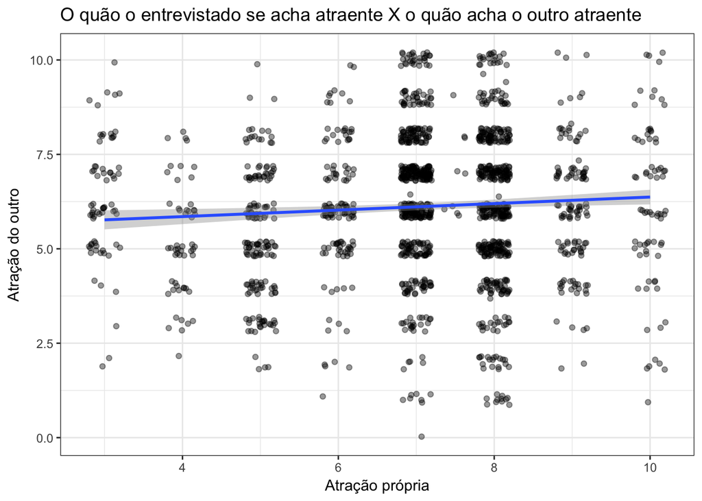

```r
ggplot(dates, aes(x = attr3_s, y = attr)) +
  geom_jitter(alpha = 0.4, width = 0.2) + geom_smooth(method = "lm") +
  labs(title="O quão o entrevistado se acha atraente X o quão acha o outro atraente",
       x="Atração própria", y="Atração do outro")
```

No gráfico acima se tem uma primeira impressão de que uma variável não explica muito, quiça alguma coisa, sobre a outra.

```r
set.seed(1)
mod <- lm(attr ~ attr3_s, data = dates)
tidy(mod, conf.int = TRUE)
```

```
##          term   estimate  std.error statistic       p.value  conf.low
## 1 (Intercept) 5.50801264 0.21353119 25.794885 3.279831e-123 5.0891863
## 2     attr3_s 0.08622455 0.02957356  2.915596  3.598906e-03 0.0282181
##   conf.high
## 1  5.926839
## 2  0.144231
```

Apesar de ter alguma significância, a “atração própria” não influencia muito no valor atribuído a atração do outro. A cada ponto a mais de atração própria a atração do outro aumenta em 0.08 ponto.

```r
glance(mod)
```

```
##     r.squared adj.r.squared    sigma statistic     p.value df    logLik
## 1 0.005219954   0.004605892 1.875471  8.500699 0.003598906  2 -3320.528
##        AIC      BIC deviance df.residual
## 1 6647.057 6663.231 5698.175        1620
```

Como já observado, a variável independente, a atração própria atribuída, não explica muito da variável dependente do modelo, a atração do outro. Nesse caso, de acordo com o R quadrado ajustado, explica somente cerca de 0.4%.